# Predict Bike Sharing Demand with AutoGluon Template

## Project: Predict Bike Sharing Demand with AutoGluon

This notebook is a template with each step that you need to complete for the project.

Please fill in your code where there are explicit `?` markers in the notebook. You are welcome to add more cells and code as you see fit.

Once you have completed all the code implementations, please export your notebook as a HTML file so the reviews can view your code. Make sure you have all outputs correctly outputted.

`File-> Export Notebook As... -> Export Notebook as HTML`

There is a writeup to complete as well after all code implememtation is done. Please answer all questions and attach the necessary tables and charts. You can complete the writeup in either markdown or PDF.

Completing the code template and writeup template will cover all of the rubric points for this project.

The rubric contains "Stand Out Suggestions" for enhancing the project beyond the minimum requirements. The stand out suggestions are optional. If you decide to pursue the "stand out suggestions", you can include the code in this notebook and also discuss the results in the writeup file.

## Step 1: Create an account with Kaggle

### Create Kaggle Account and download API key

Below is example of steps to get the API username and key. Each student will have their own username and key.

1. Open account settings.

2. Scroll down to API and click Create New API Token.

3. Open up `kaggle.json` and use the username and key.


## Step 2: Download the Kaggle dataset using the kaggle python library

### Open up Sagemaker Studio and use starter template

1. Notebook should be using a `ml.t3.medium` instance (2 vCPU + 4 GiB)
2. Notebook should be using kernal: `Python 3 (MXNet 1.8 Python 3.7 CPU Optimized)`

### Install packages

```python
%pip install -U pip
%pip install -U setuptools wheel
%pip install -U "mxnet<2.0.0" bokeh==2.0.1
%pip install autogluon --no-cache-dir
# Without --no-cache-dir, smaller aws instances may have trouble installing
```

### Setup Kaggle API Key

```python
# create the .kaggle directory and an empty kaggle.json file
!mkdir -p /home/nam/.kaggle
!touch /home/nam/.kaggle/kaggle.json
!chmod 600 /home/nam/.kaggle/kaggle.json
```

```python
# Fill in your user name and key from creating the kaggle account and API token file
import json
kaggle_username = ""
kaggle_key = ""

# Save API token the kaggle.json file
with open("/home/nam/.kaggle/kaggle.json", "w") as f:
    f.write(json.dumps({"username": kaggle_username, "key": kaggle_key}))
```

### Download and explore dataset

### Go to the [bike sharing demand competition](https://www.kaggle.com/c/bike-sharing-demand) and agree to the terms

```python
# # Download the dataset, it will be in a .zip file so you'll need to unzip it as well.
# !kaggle competitions download -c bike-sharing-demand
# # If you already downloaded it you can use the -o command to overwrite the file
# !unzip -o bike-sharing-demand.zip
```

```python
import subprocess
import zipfile
import os

# Download the dataset
subprocess.run(['kaggle', 'competitions', 'download', '-c', 'bike-sharing-demand'], check=True)

# Unzip the dataset
with zipfile.ZipFile('bike-sharing-demand.zip', 'r') as zip_ref:
    zip_ref.extractall()

# Optionally, you can overwrite the existing files by setting the 'extractall' method's 'members' parameter
# to a list of files you want to extract.
```

```python
import pandas as pd
from autogluon.tabular import TabularPredictor
```

```python
# Create the train dataset in pandas by reading the csv
# Set the parsing of the datetime column so you can use some of the `dt` features in pandas later
train = pd.read_csv("./train.csv", parse_dates=["datetime"]).drop(columns=["casual", "registered"])
train.head()
```

|  | datetime | season | holiday | workingday | weather | temp | atemp | humidity | windspeed | count |
| --- | --- | --- | --- | --- | --- | --- | --- | --- | --- | --- |
| 0 | 2011-01-01 00:00:00 | 1 | 0 | 0 | 1 | 9.84 | 14.395 | 81 | 0.0 | 16 |
| 1 | 2011-01-01 01:00:00 | 1 | 0 | 0 | 1 | 9.02 | 13.635 | 80 | 0.0 | 40 |
| 2 | 2011-01-01 02:00:00 | 1 | 0 | 0 | 1 | 9.02 | 13.635 | 80 | 0.0 | 32 |
| 3 | 2011-01-01 03:00:00 | 1 | 0 | 0 | 1 | 9.84 | 14.395 | 75 | 0.0 | 13 |
| 4 | 2011-01-01 04:00:00 | 1 | 0 | 0 | 1 | 9.84 | 14.395 | 75 | 0.0 | 1 |

```python
# Simple output of the train dataset to view some of the min/max/varition of the dataset features.
train.describe()
```

|  | datetime | season | holiday | workingday | weather | temp | atemp | humidity | windspeed | count |
| --- | --- | --- | --- | --- | --- | --- | --- | --- | --- | --- |
| count | 10886 | 10886.000000 | 10886.000000 | 10886.000000 | 10886.000000 | 10886.00000 | 10886.000000 | 10886.000000 | 10886.000000 | 10886.000000 |
| mean | 2011-12-27 05:56:22.399411968 | 2.506614 | 0.028569 | 0.680875 | 1.418427 | 20.23086 | 23.655084 | 61.886460 | 12.799395 | 191.574132 |
| min | 2011-01-01 00:00:00 | 1.000000 | 0.000000 | 0.000000 | 1.000000 | 0.82000 | 0.760000 | 0.000000 | 0.000000 | 1.000000 |
| 25% | 2011-07-02 07:15:00 | 2.000000 | 0.000000 | 0.000000 | 1.000000 | 13.94000 | 16.665000 | 47.000000 | 7.001500 | 42.000000 |
| 50% | 2012-01-01 20:30:00 | 3.000000 | 0.000000 | 1.000000 | 1.000000 | 20.50000 | 24.240000 | 62.000000 | 12.998000 | 145.000000 |
| 75% | 2012-07-01 12:45:00 | 4.000000 | 0.000000 | 1.000000 | 2.000000 | 26.24000 | 31.060000 | 77.000000 | 16.997900 | 284.000000 |
| max | 2012-12-19 23:00:00 | 4.000000 | 1.000000 | 1.000000 | 4.000000 | 41.00000 | 45.455000 | 100.000000 | 56.996900 | 977.000000 |
| std | NaN | 1.116174 | 0.166599 | 0.466159 | 0.633839 | 7.79159 | 8.474601 | 19.245033 | 8.164537 | 181.144454 |

```python
# Create the test pandas dataframe in pandas by reading the csv, remember to parse the datetime!
test = pd.read_csv("./test.csv", parse_dates=["datetime"])
test.head()
```

|  | datetime | season | holiday | workingday | weather | temp | atemp | humidity | windspeed |
| --- | --- | --- | --- | --- | --- | --- | --- | --- | --- |
| 0 | 2011-01-20 00:00:00 | 1 | 0 | 1 | 1 | 10.66 | 11.365 | 56 | 26.0027 |
| 1 | 2011-01-20 01:00:00 | 1 | 0 | 1 | 1 | 10.66 | 13.635 | 56 | 0.0000 |
| 2 | 2011-01-20 02:00:00 | 1 | 0 | 1 | 1 | 10.66 | 13.635 | 56 | 0.0000 |
| 3 | 2011-01-20 03:00:00 | 1 | 0 | 1 | 1 | 10.66 | 12.880 | 56 | 11.0014 |
| 4 | 2011-01-20 04:00:00 | 1 | 0 | 1 | 1 | 10.66 | 12.880 | 56 | 11.0014 |

```python
# Same thing as train and test dataset
submission = pd.read_csv("./sampleSubmission.csv")
submission.head()
```

|  | datetime | count |
| --- | --- | --- |
| 0 | 2011-01-20 00:00:00 | 0 |
| 1 | 2011-01-20 01:00:00 | 0 |
| 2 | 2011-01-20 02:00:00 | 0 |
| 3 | 2011-01-20 03:00:00 | 0 |
| 4 | 2011-01-20 04:00:00 | 0 |

## Step 3: Train a model using AutoGluon’s Tabular Prediction

```python
predictor = TabularPredictor(label="count", eval_metric="r2").fit(
    train_data=train,
    time_limit=600,
    presets="best_quality",
)
```

[output not shown]

[output cut: 257 more lines]

```
	0.9205	 = Validation score   (r2)
	20.37s	 = Training   runtime
	0.21s	 = Validation runtime
Fitting model: CatBoost_r9_BAG_L2 ... Training model for up to 13.79s of the 13.64s of remaining time.
	Fitting 8 child models (S1F1 - S1F8) | Fitting with ParallelLocalFoldFittingStrategy (8 workers, per: cpus=3, gpus=0, memory=0.85%)
	0.9068	 = Validation score   (r2)
	11.44s	 = Training   runtime
	0.04s	 = Validation runtime
Fitting model: WeightedEnsemble_L3 ... Training model for up to 360.0s of the 0.55s of remaining time.
	Ensemble Weights: {'NeuralNetFastAI_r191_BAG_L2': 0.45, 'RandomForestMSE_BAG_L2': 0.25, 'NeuralNetTorch_r79_BAG_L2': 0.2, 'NeuralNetTorch_BAG_L2': 0.1}
	0.924	 = Validation score   (r2)
	0.12s	 = Training   runtime
	0.0s	 = Validation runtime
AutoGluon training complete, total runtime = 438.62s ... Best model: WeightedEnsemble_L3 | Estimated inference throughput: 135.8 rows/s (1361 batch size)
TabularPredictor saved. To load, use: predictor = TabularPredictor.load("AutogluonModels/ag-20241021_175256")
```

### Review AutoGluon's training run with ranking of models that did the best.

```python
predictor.fit_summary()
```

```
*** Summary of fit() ***
Estimated performance of each model:
                          model  score_val eval_metric  pred_time_val    fit_time  pred_time_val_marginal  fit_time_marginal  stack_level  can_infer  fit_order
0           WeightedEnsemble_L3   0.923985          r2      11.117398  353.876401                0.000453           0.118922            3       True         40
1   NeuralNetFastAI_r191_BAG_L2   0.920505          r2      10.599729  294.950660                0.206244          20.370447            2       True         38
2        NeuralNetFastAI_BAG_L2   0.916398          r2      10.508275  283.110634                0.114790           8.530421            2       True         31
3     NeuralNetTorch_r79_BAG_L2   0.916177          r2      10.528953  298.945566                0.135468          24.365354            2       True         36
4        RandomForestMSE_BAG_L2   0.913034          r2      10.662502  278.001178                0.269017           3.420965            2       True         28
5          LightGBMLarge_BAG_L2   0.908115          r2      10.453464  277.571748                0.059979           2.991535            2       True         34
6               LightGBM_BAG_L2   0.907542          r2      10.457181  276.440287                0.063696           1.860074            2       True         27
7          ExtraTreesMSE_BAG_L2   0.907471          r2      10.640243  275.259576                0.246758           0.679363            2       True         30
8         NeuralNetTorch_BAG_L2   0.907149          r2      10.506217  305.600714                0.112732          31.020502            2       True         33
9            CatBoost_r9_BAG_L2   0.906795          r2      10.430714  286.023736                0.037229          11.443523            2       True         39
10               XGBoost_BAG_L2   0.906297          r2      10.434127  276.693590                0.040642           2.113378            2       True         32
11         LightGBM_r131_BAG_L2   0.906152          r2      10.781730  280.348612                0.388245           5.768399            2       True         37
```

[output cut: 40 more lines]

[output not shown]

[output cut: 441 more lines]

```
 25       True         11
 26       True          6
 27       True         12
 28       True         23
 29       True          4
 30       True          3
 31       True          9
 32       True         21
 33       True         17
 34       True         15
 35       True          8
 36       True         10
 37       True         22
 38       True         13
 39       True         18  }
```

### Create predictions from test dataset

```python
test["count"] = predictor.predict(test)
predictions = predictor.evaluate(test)
```

```python
predictions
```

```
{'r2': 1.0,
 'root_mean_squared_error': -0.0,
 'mean_squared_error': -0.0,
 'mean_absolute_error': -0.0,
 'pearsonr': 1.0,
 'median_absolute_error': -0.0}
```

#### NOTE: Kaggle will reject the submission if we don't set everything to be > 0.

```python
# Describe the `predictions` series to see if there are any negative values
test["count"].describe()
```

```
count    6493.000000
mean       99.091202
std        88.902222
min         2.663233
25%        19.209007
50%        64.699295
75%       168.845886
max       349.032715
Name: count, dtype: float64
```

```python
# How many negative values do we have?
print((test["count"] < 0).sum())
```

```
0
```

```python
# Set them to zero
test.loc[test["count"] < 0, "count"] = 0
```

### Set predictions to submission dataframe, save, and submit

```python
submission["count"] = test["count"]
submission.to_csv("submission.csv", index=False)
```

```python
!kaggle competitions submit -c bike-sharing-demand -f submission.csv -m "first raw submission"
```

```
Successfully submitted to Bike Sharing Demand
```

#### View submission via the command line or in the web browser under the competition's page - `My Submissions`

```python
!kaggle competitions submissions -c bike-sharing-demand | tail -n +1 | head -n 6
```

```
fileName        date                 description           status    publicScore  privateScore
--------------  -------------------  --------------------  --------  -----------  ------------
submission.csv  2024-10-21 16:34:30  first raw submission  complete  1.83617      1.83617
```

## Step 4: Exploratory Data Analysis and Creating an additional feature

- Any additional feature will do, but a great suggestion would be to separate out the datetime into hour, day, or month parts.

```
array([[<Axes: title={'center': 'datetime'}>,
        <Axes: title={'center': 'season'}>,
        <Axes: title={'center': 'holiday'}>],
       [<Axes: title={'center': 'workingday'}>,
        <Axes: title={'center': 'weather'}>,
        <Axes: title={'center': 'temp'}>],
       [<Axes: title={'center': 'atemp'}>,
        <Axes: title={'center': 'humidity'}>,
        <Axes: title={'center': 'windspeed'}>],
       [<Axes: title={'center': 'count'}>, <Axes: >, <Axes: >]],
      dtype=object)
```

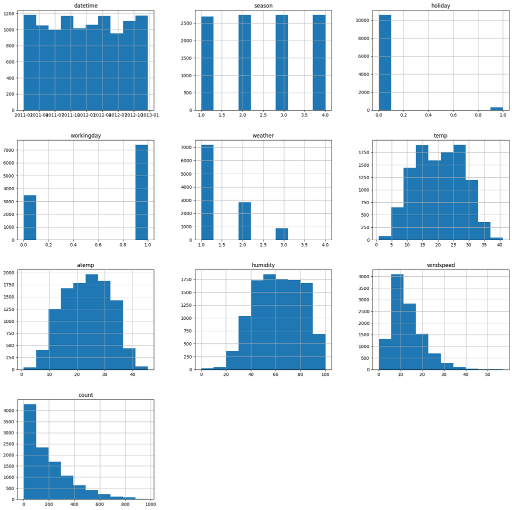

```python
# Create a histogram of all features to show the distribution of each one relative to the data. This is part of the exploritory data analysis
train.hist(figsize=(20, 20))
```

```python
train.info()
```

```
<class 'pandas.core.frame.DataFrame'>
RangeIndex: 10886 entries, 0 to 10885
Data columns (total 10 columns):
 #   Column      Non-Null Count  Dtype
---  ------      --------------  -----
 0   datetime    10886 non-null  datetime64[ns]
 1   season      10886 non-null  int64
 2   holiday     10886 non-null  int64
 3   workingday  10886 non-null  int64
 4   weather     10886 non-null  int64
 5   temp        10886 non-null  float64
 6   atemp       10886 non-null  float64
 7   humidity    10886 non-null  int64
 8   windspeed   10886 non-null  float64
 9   count       10886 non-null  int64
dtypes: datetime64[ns](1), float64(3), int64(6)
memory usage: 850.6 KB
```

```python
# create a new feature
train["hour"] = train["datetime"].dt.hour
train["day"] = train["datetime"].dt.day
train["month"] = train["datetime"].dt.month
train["year"] = train["datetime"].dt.year
train["weekday"] = train["datetime"].dt.weekday

test["hour"] = test["datetime"].dt.hour
test["day"] = test["datetime"].dt.day
test["month"] = test["datetime"].dt.month
test["year"] = test["datetime"].dt.year
test["weekday"] = test["datetime"].dt.weekday
```

## Make category types for these so models know they are not just numbers

- AutoGluon originally sees these as ints, but in reality they are int representations of a category.
- Setting the dtype to category will classify these as categories in AutoGluon.

```python
train["season"] = train["season"].astype("category")
train["weather"] = train["weather"].astype("category")
test["season"] = test["season"].astype("category")
test["weather"] = test["weather"].astype("category")
```

```python
# View are new feature
train.head()
```

|  | datetime | season | holiday | workingday | weather | temp | atemp | humidity | windspeed | count | hour | day | month | year | weekday |
| --- | --- | --- | --- | --- | --- | --- | --- | --- | --- | --- | --- | --- | --- | --- | --- |
| 0 | 2011-01-01 00:00:00 | 1 | 0 | 0 | 1 | 9.84 | 14.395 | 81 | 0.0 | 16 | 0 | 1 | 1 | 2011 | 5 |
| 1 | 2011-01-01 01:00:00 | 1 | 0 | 0 | 1 | 9.02 | 13.635 | 80 | 0.0 | 40 | 1 | 1 | 1 | 2011 | 5 |
| 2 | 2011-01-01 02:00:00 | 1 | 0 | 0 | 1 | 9.02 | 13.635 | 80 | 0.0 | 32 | 2 | 1 | 1 | 2011 | 5 |
| 3 | 2011-01-01 03:00:00 | 1 | 0 | 0 | 1 | 9.84 | 14.395 | 75 | 0.0 | 13 | 3 | 1 | 1 | 2011 | 5 |
| 4 | 2011-01-01 04:00:00 | 1 | 0 | 0 | 1 | 9.84 | 14.395 | 75 | 0.0 | 1 | 4 | 1 | 1 | 2011 | 5 |

```python
train.info()
```

```
<class 'pandas.core.frame.DataFrame'>
RangeIndex: 10886 entries, 0 to 10885
Data columns (total 15 columns):
 #   Column      Non-Null Count  Dtype
---  ------      --------------  -----
 0   datetime    10886 non-null  datetime64[ns]
 1   season      10886 non-null  category
 2   holiday     10886 non-null  int64
 3   workingday  10886 non-null  int64
 4   weather     10886 non-null  category
 5   temp        10886 non-null  float64
 6   atemp       10886 non-null  float64
 7   humidity    10886 non-null  int64
 8   windspeed   10886 non-null  float64
 9   count       10886 non-null  int64
 10  hour        10886 non-null  int32
 11  day         10886 non-null  int32
 12  month       10886 non-null  int32
 13  year        10886 non-null  int32
 14  weekday     10886 non-null  int32
dtypes: category(2), datetime64[ns](1), float64(3), int32(5), int64(4)
memory usage: 914.8 KB
```

```
array([[<Axes: title={'center': 'datetime'}>,
        <Axes: title={'center': 'holiday'}>,
        <Axes: title={'center': 'workingday'}>,
        <Axes: title={'center': 'temp'}>],
       [<Axes: title={'center': 'atemp'}>,
        <Axes: title={'center': 'humidity'}>,
        <Axes: title={'center': 'windspeed'}>,
        <Axes: title={'center': 'count'}>],
       [<Axes: title={'center': 'hour'}>,
        <Axes: title={'center': 'day'}>,
        <Axes: title={'center': 'month'}>,
        <Axes: title={'center': 'year'}>],
       [<Axes: title={'center': 'weekday'}>, <Axes: >, <Axes: >,
        <Axes: >]], dtype=object)
```

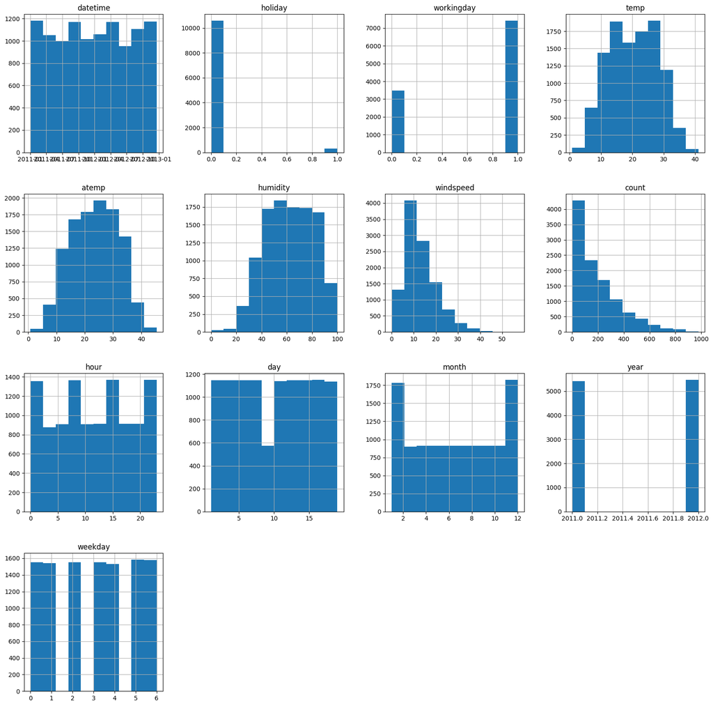

```python
# View histogram of all features again now with the hour feature
train.hist(figsize=(20, 20))
```

## Step 5: Rerun the model with the same settings as before, just with more features

```python
predictor_new_features = TabularPredictor(label="count", eval_metric="r2").fit(
    train_data=train,
    time_limit=600,
    presets="best_quality",
)
```

[output not shown]

[output cut: 220 more lines]

```
	0.9752	 = Validation score   (r2)
	23.4s	 = Training   runtime
	0.25s	 = Validation runtime
Fitting model: CatBoost_r9_BAG_L2 ... Training model for up to 15.69s of the 15.62s of remaining time.
	Fitting 8 child models (S1F1 - S1F8) | Fitting with ParallelLocalFoldFittingStrategy (8 workers, per: cpus=3, gpus=0, memory=0.77%)
	0.9725	 = Validation score   (r2)
	12.88s	 = Training   runtime
	0.07s	 = Validation runtime
Fitting model: WeightedEnsemble_L3 ... Training model for up to 360.0s of the 1.13s of remaining time.
	Ensemble Weights: {'NeuralNetFastAI_r191_BAG_L2': 0.611, 'NeuralNetTorch_r79_BAG_L2': 0.278, 'CatBoost_r177_BAG_L2': 0.111}
	0.9756	 = Validation score   (r2)
	0.12s	 = Training   runtime
	0.0s	 = Validation runtime
AutoGluon training complete, total runtime = 440.22s ... Best model: WeightedEnsemble_L3 | Estimated inference throughput: 212.5 rows/s (1361 batch size)
TabularPredictor saved. To load, use: predictor = TabularPredictor.load("AutogluonModels/ag-20241021_180453")
```

```python
predictor_new_features.fit_summary()
```

```
*** Summary of fit() ***
Estimated performance of each model:
                          model  score_val eval_metric  pred_time_val    fit_time  pred_time_val_marginal  fit_time_marginal  stack_level  can_infer  fit_order
0           WeightedEnsemble_L3   0.975644          r2       6.890653  347.141951                0.000401           0.116515            3       True         32
1   NeuralNetFastAI_r191_BAG_L2   0.975217          r2       6.727342  303.946848                0.254469          23.395608            2       True         30
2     NeuralNetTorch_r79_BAG_L2   0.973850          r2       6.605870  318.773702                0.132998          38.222463            2       True         28
3        NeuralNetFastAI_BAG_L2   0.973507          r2       6.617264  289.483963                0.144391           8.932724            2       True         23
4            CatBoost_r9_BAG_L2   0.972506          r2       6.541204  293.432961                0.068331          12.881722            2       True         31
5          CatBoost_r177_BAG_L2   0.972340          r2       6.502786  285.407365                0.029913           4.856125            2       True         27
6               CatBoost_BAG_L2   0.971936          r2       6.501665  293.259185                0.028792          12.707946            2       True         21
7               LightGBM_BAG_L2   0.971869          r2       6.528774  281.909299                0.055902           1.358059            2       True         19
8          LightGBM_r131_BAG_L2   0.971660          r2       6.664364  283.005996                0.191492           2.454756            2       True         29
9             LightGBMXT_BAG_L2   0.971176          r2       4.401670  281.773457               -2.071202           1.222217            2       True         18
10               XGBoost_BAG_L2   0.970886          r2       6.524785  282.282938                0.051912           1.731698            2       True         24
11         LightGBMLarge_BAG_L2   0.970351          r2       6.560468  283.319258                0.087595           2.768019            2       True         26
12         ExtraTreesMSE_BAG_L2   0.970311          r2       6.725534  281.129400                0.252662           0.578161            2       True         22
13        NeuralNetTorch_BAG_L2   0.969935          r2       6.603042  302.324872                0.130170          21.773633            2       True         25
14          WeightedEnsemble_L2   0.969741          r2       2.977318  190.360143                0.000517           0.075402            2       True         17
15       RandomForestMSE_BAG_L2   0.969717          r2       6.753353  283.260963                0.280480           2.709724            2       True         20
16         CatBoost_r177_BAG_L1   0.966857          r2       0.035064   41.042070                0.035064          41.042070            1       True         12
17              CatBoost_BAG_L1   0.966574          r2       0.127283   80.693744                0.127283          80.693744            1       True          6
18         LightGBM_r131_BAG_L1   0.966162          r2       2.480530    8.647018                2.480530           8.647018            1       True         14
19         LightGBMLarge_BAG_L1   0.965654          r2       0.462030    9.479023                0.462030           9.479023            1       True         11
20              LightGBM_BAG_L1   0.964938          r2       0.386192    3.558746                0.386192           3.558746            1       True          4
21            LightGBMXT_BAG_L1   0.963663          r2       1.648371    7.681525                1.648371           7.681525            1       True          3
22               XGBoost_BAG_L1   0.963495          r2       0.243480    3.578621                0.243480           3.578621            1       True          9
23           CatBoost_r9_BAG_L1   0.963050          r2       0.064580    3.497399                0.064580           3.497399            1       True         16
24       RandomForestMSE_BAG_L1   0.955044          r2       0.254690    0.668803                0.254690           0.668803            1       True          5
25         ExtraTreesMSE_BAG_L1   0.955044          r2       0.255125    0.472832                0.255125           0.472832            1       True          7
26        NeuralNetTorch_BAG_L1   0.950459          r2       0.056880   44.236890                0.056880          44.236890            1       True         10
27  NeuralNetFastAI_r191_BAG_L1   0.944514          r2       0.203726   23.417356                0.203726          23.417356            1       True         15
28       NeuralNetFastAI_BAG_L1   0.937187          r2       0.137689    9.292117                0.137689           9.292117            1       True          8
```

[output cut: 16 more lines]

[output not shown]

[output cut: 343 more lines]

```
 17       True          6
 18       True         14
 19       True         11
 20       True          4
 21       True          3
 22       True          9
 23       True         16
 24       True          5
 25       True          7
 26       True         10
 27       True         15
 28       True          8
 29       True         13
 30       True          2
 31       True          1  }
```

```python
# Remember to set all negative values to zero
test["count"] = predictor_new_features.predict(test)
test["count"].describe()
```

```
count    6493.000000
mean      125.052086
std       106.725555
min         0.744556
25%        50.940777
50%        95.929802
75%       166.396179
max       730.892578
Name: count, dtype: float64
```

```python
# Check if there are any values less than 0 in the 'count' column of the test DataFrame
negative_count_values = test[test["count"] < 0]

# Print the result
if not negative_count_values.empty:
    print("There are values less than 0 in the 'count' column:")
    print(negative_count_values)
else:
    print("There are no values less than 0 in the 'count' column.")
```

```
There are no values less than 0 in the 'count' column.
```

```python
test.head()
```

|  | datetime | season | holiday | workingday | weather | temp | atemp | humidity | windspeed | count | hour | day | month | year | weekday |
| --- | --- | --- | --- | --- | --- | --- | --- | --- | --- | --- | --- | --- | --- | --- | --- |
| 0 | 2011-01-20 00:00:00 | 1 | 0 | 1 | 1 | 10.66 | 11.365 | 56 | 26.0027 | 16.006853 | 0 | 20 | 1 | 2011 | 3 |
| 1 | 2011-01-20 01:00:00 | 1 | 0 | 1 | 1 | 10.66 | 13.635 | 56 | 0.0000 | 7.170821 | 1 | 20 | 1 | 2011 | 3 |
| 2 | 2011-01-20 02:00:00 | 1 | 0 | 1 | 1 | 10.66 | 13.635 | 56 | 0.0000 | 6.206450 | 2 | 20 | 1 | 2011 | 3 |
| 3 | 2011-01-20 03:00:00 | 1 | 0 | 1 | 1 | 10.66 | 12.880 | 56 | 11.0014 | 7.531336 | 3 | 20 | 1 | 2011 | 3 |
| 4 | 2011-01-20 04:00:00 | 1 | 0 | 1 | 1 | 10.66 | 12.880 | 56 | 11.0014 | 7.676744 | 4 | 20 | 1 | 2011 | 3 |

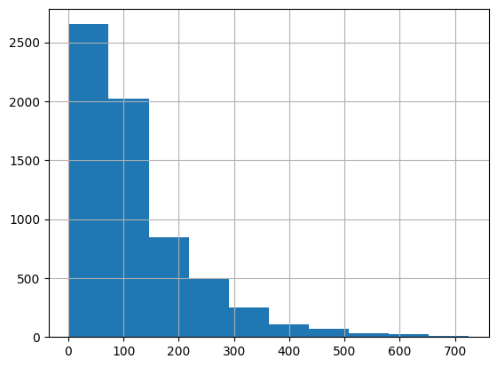

```python
test["count"].hist()
```

```python
# Same submitting predictions
submission_new_features = pd.read_csv("./sampleSubmission.csv")
submission_new_features["count"] = test["count"]
submission_new_features.to_csv("submission_new_features.csv", index=False)
```

```python
!kaggle competitions submit -c bike-sharing-demand -f submission_new_features.csv -m "new features"
```

```
Successfully submitted to Bike Sharing Demand
```

```python
!kaggle competitions submissions -c bike-sharing-demand | tail -n +1 | head -n 6
```

```
fileName                     date                 description           status    publicScore  privateScore
---------------------------  -------------------  --------------------  --------  -----------  ------------
submission_new_features.csv  2024-10-21 16:57:49  new features          complete  0.91002      0.91002
submission.csv               2024-10-21 16:34:30  first raw submission  complete  1.83617      1.83617
```

## Step 6: Hyper parameter optimization

- There are many options for hyper parameter optimization.
- Options are to change the AutoGluon higher level parameters or the individual model hyperparameters.
- The hyperparameters of the models themselves that are in AutoGluon. Those need the `hyperparameter` and `hyperparameter_tune_kwargs` arguments.

```python
hyperparameters = {
    'GBM': {
        'num_leaves': 31,
        'learning_rate': 0.05,
        'n_estimators': 100,
    },
    'XGB': {
        'max_depth': 6,
        'eta': 0.1,
        'subsample': 0.8,
    },
    'CAT': {
        'depth': 6,
        'learning_rate': 0.03,
        'iterations': 500,
    }
}

predictor_new_hpo = TabularPredictor(label="count", eval_metric="r2").fit(
    train_data=train,
    time_limit=600,
    presets="best_quality",
    hyperparameters=hyperparameters,
    hyperparameter_tune_kwargs={
        'num_trials': 10,
        'scheduler': 'local',
        'searcher': 'random'
    }
)
```

```
No path specified. Models will be saved in: "AutogluonModels/ag-20241021_170406"
Verbosity: 2 (Standard Logging)
=================== System Info ===================
AutoGluon Version:  1.1.1
Python Version:     3.10.15
Operating System:   Linux
Platform Machine:   x86_64
Platform Version:   #1 SMP Fri Mar 29 23:14:13 UTC 2024
CPU Count:          28
Memory Avail:       9.56 GB / 15.49 GB (61.7%)
Disk Space Avail:   281.54 GB / 300.00 GB (93.8%)
===================================================
Presets specified: ['best_quality']
Warning: hyperparameter tuning is currently experimental and may cause the process to hang.
Setting dynamic_stacking from 'auto' to True. Reason: Enable dynamic_stacking when use_bag_holdout is disabled. (use_bag_holdout=False)
Stack configuration (auto_stack=True): num_stack_levels=1, num_bag_folds=8, num_bag_sets=1
DyStack is enabled (dynamic_stacking=True). AutoGluon will try to determine whether the input data is affected by stacked overfitting and enable or disable stacking as a consequence.
	This is used to identify the optimal `num_stack_levels` value. Copies of AutoGluon will be fit on subsets of the data. Then holdout validation data is used to detect stacked overfitting.
	Running DyStack for up to 150s of the 600s of remaining time (25%).
		Context path: "AutogluonModels/ag-20241021_170406/ds_sub_fit/sub_fit_ho"
Leaderboard on holdout data (DyStack):
                  model  score_holdout  score_val eval_metric  pred_time_test  pred_time_val   fit_time  pred_time_test_marginal  pred_time_val_marginal  fit_time_marginal  stack_level  can_infer  fit_order
0     XGBoost_BAG_L1/T2       0.967547   0.962221          r2       -1.943195       0.208958   3.773390                -1.943195                0.208958           3.773390            1       True         22
1   WeightedEnsemble_L3       0.967432   0.964954          r2        4.185224       3.779808  73.595637                 0.008356                0.000415           0.089310            3       True         52
2     XGBoost_BAG_L1/T4       0.967206   0.963999          r2        1.277042       0.677945   8.754830                 1.277042                0.677945           8.754830            1       True         24
3   WeightedEnsemble_L2       0.967111   0.964840          r2        3.859400       2.722042  24.023143                 0.007650                0.000468           0.086526            2       True         26
4     XGBoost_BAG_L2/T2       0.967106   0.963356          r2        3.684121       3.550464  63.951955                 0.325857                0.058547           2.489372            2       True         45
5     XGBoost_BAG_L2/T1       0.967088   0.963181          r2        3.677294       3.543379  64.075371                 0.319029                0.051461           2.612788            2       True         44
6   LightGBM_BAG_L2/T10       0.967071   0.963025          r2        3.425099       3.518479  62.818856                 0.066834                0.026561           1.356273            2       True         36
7    LightGBM_BAG_L2/T6       0.967050   0.963046          r2        3.428886       3.520058  62.766394                 0.070621                0.028140           1.303811            2       True         32
8    LightGBM_BAG_L2/T4       0.967041   0.963063          r2        3.427418       3.517370  62.823116                 0.069153                0.025452           1.360533            2       True         30
9     XGBoost_BAG_L2/T7       0.967032   0.963718          r2        3.791042       3.669364  66.787402                 0.432778                0.177447           5.324819            2       True         50
10    XGBoost_BAG_L2/T5       0.967027   0.963394          r2        3.713521       3.571317  64.903243                 0.355256                0.079399           3.440660            2       True         48
11    XGBoost_BAG_L2/T3       0.967016   0.963262          r2        3.711567       3.542172  63.747250                 0.353302                0.050254           2.284668            2       True         46
12    XGBoost_BAG_L2/T4       0.966970   0.963499          r2        3.697098       3.562248  64.322037                 0.338834                0.070331           2.859454            2       True         47
13    XGBoost_BAG_L2/T6       0.966952   0.963009          r2        3.700767       3.540635  63.786775                 0.342502                0.048717           2.324192            2       True         49
14   LightGBM_BAG_L2/T3       0.966951   0.962699          r2        3.425760       3.519833  60.311659                 0.067496                0.027915          -1.150923            2       True         29
15   LightGBM_BAG_L2/T9       0.966928   0.963045          r2        3.424494       3.518416  62.812504                 0.066230                0.026498           1.349921            2       True         35
16   LightGBM_BAG_L2/T5       0.966925   0.963173          r2        3.428414       3.517899  62.915458                 0.070149                0.025981           1.452876            2       True         31
17   LightGBM_BAG_L2/T1       0.966893   0.962874          r2        3.438135       3.518005  62.787969                 0.079870                0.026088           1.325387            2       True         27
```

[output cut: 334 more lines]

```
Fitted model: XGBoost_BAG_L2/T9 ...
	0.9649	 = Validation score   (r2)
	2.72s	 = Training   runtime
	0.06s	 = Validation runtime
Fitted model: XGBoost_BAG_L2/T10 ...
	0.9649	 = Validation score   (r2)
	2.61s	 = Training   runtime
	0.06s	 = Validation runtime
Fitting model: WeightedEnsemble_L3 ... Training model for up to 360.0s of the 272.61s of remaining time.
	Ensemble Weights: {'XGBoost_BAG_L1/T5': 0.28, 'XGBoost_BAG_L1/T4': 0.16, 'CatBoost_BAG_L2/T6': 0.16, 'LightGBM_BAG_L2/T4': 0.12, 'XGBoost_BAG_L2/T4': 0.12, 'CatBoost_BAG_L2/T1': 0.08, 'LightGBM_BAG_L2/T7': 0.04, 'XGBoost_BAG_L2/T7': 0.04}
	0.9667	 = Validation score   (r2)
	0.08s	 = Training   runtime
	0.0s	 = Validation runtime
AutoGluon training complete, total runtime = 194.93s ... Best model: WeightedEnsemble_L3 | Estimated inference throughput: 60.9 rows/s (1361 batch size)
TabularPredictor saved. To load, use: predictor = TabularPredictor.load("AutogluonModels/ag-20241021_170406")
```

```python
predictor_new_hpo.fit_summary()
```

```
*** Summary of fit() ***
Estimated performance of each model:
                  model  score_val eval_metric  pred_time_val    fit_time  pred_time_val_marginal  fit_time_marginal  stack_level  can_infer  fit_order
0   WeightedEnsemble_L3   0.966676          r2      22.356330  127.261445                0.000439           0.077372            3       True         62
1   WeightedEnsemble_L2   0.966379          r2       9.944554   48.024013                0.000613           0.073000            2       True         31
2     XGBoost_BAG_L2/T7   0.965795          r2      22.141801  115.262120                0.217969           6.134196            2       True         58
3     XGBoost_BAG_L1/T5   0.965752          r2       1.164317   11.462842                1.164317          11.462842            1       True         25
4    CatBoost_BAG_L2/T1   0.965752          r2      21.957568  113.310960                0.033736           4.183036            2       True         42
5    CatBoost_BAG_L2/T6   0.965732          r2      21.962268  113.362885                0.038436           4.234960            2       True         47
6     XGBoost_BAG_L1/T8   0.965724          r2       9.547534   16.993227                9.547534          16.993227            1       True         28
7   LightGBM_BAG_L2/T10   0.965714          r2      21.950147  110.541908                0.026315           1.413984            2       True         41
8    CatBoost_BAG_L2/T5   0.965708          r2      21.969780  110.706714                0.045948           1.578790            2       True         46
9    CatBoost_BAG_L2/T2   0.965705          r2      21.960380  113.245437                0.036548           4.117512            2       True         43
10   CatBoost_BAG_L2/T7   0.965704          r2      21.958956  113.321955                0.035125           4.194031            2       True         48
11   LightGBM_BAG_L2/T7   0.965700          r2      21.954905  110.540617                0.031073           1.412693            2       True         38
```

[output cut: 63 more lines]

[output not shown]

[output cut: 546 more lines]

```

     fit_order
 0          62
 1          31
 2          58
 3          25
 4          42
 ..        ...
 57         12
 58         17
 59         19
 60         20
 61         13

 [62 rows x 10 columns]}
```

```python
# Remember to set all negative values to zero
test["count"] = predictor_new_hpo.predict(test)
test["count"].describe()
# Check if there are any values less than 0 in the 'count' column of the test DataFrame then set them to zero
test.loc[test["count"] < 0, "count"] = 0
```

```python
# Define another set of hyperparameters
hyperparameters_v2 = {
    'GBM': {
        'num_leaves': 40,
        'learning_rate': 0.03,
        'n_estimators': 150,
    },
    'XGB': {
        'max_depth': 8,
        'eta': 0.05,
        'subsample': 0.9,
    },
    'CAT': {
        'depth': 8,
        'learning_rate': 0.02,
        'iterations': 600,
    }
}

# Fit the model with the new set of hyperparameters
predictor_new_hpo_v2 = TabularPredictor(label="count", eval_metric="r2").fit(
    train_data=train,
    time_limit=600,
    presets="best_quality",
    hyperparameters=hyperparameters_v2,
    hyperparameter_tune_kwargs={
        'num_trials': 10,
        'scheduler': 'local',
        'searcher': 'random'
    }
)
```

[output not shown]

[output cut: 355 more lines]

[output not shown]

[output not shown]

[output not shown]

[output not shown]

[output not shown]

[output not shown]

[output not shown]

```python
predictor_new_hpo_v2.fit_summary()
```

```
*** Summary of fit() ***
Estimated performance of each model:
                  model  score_val eval_metric  pred_time_val    fit_time  pred_time_val_marginal  fit_time_marginal  stack_level  can_infer  fit_order
0   WeightedEnsemble_L3   0.502342          r2       3.372689  109.848422                0.000682           0.085938            3       True         62
1    CatBoost_BAG_L2/T2   0.501671          r2       3.180223   78.453657                0.030500          10.935917            2       True         43
2    CatBoost_BAG_L2/T3   0.501542          r2       3.180973   77.136472                0.031251           9.618732            2       True         44
3    CatBoost_BAG_L2/T6   0.501506          r2       3.173757   77.704413                0.024035          10.186673            2       True         47
4    CatBoost_BAG_L2/T9   0.501406          r2       3.172899   79.016408                0.023177          11.498669            2       True         50
5    CatBoost_BAG_L2/T1   0.501400          r2       3.179048   78.588289                0.029326          11.070549            2       True         42
6    CatBoost_BAG_L2/T8   0.501336          r2       3.175884   76.716778                0.026162           9.199038            2       True         49
7    CatBoost_BAG_L2/T5   0.501310          r2       3.172216   76.144250                0.022494           8.626511            2       True         46
8   CatBoost_BAG_L2/T10   0.501125          r2       3.175806   78.621560                0.026083          11.103820            2       True         51
9    CatBoost_BAG_L2/T4   0.501035          r2       3.178867   79.099662                0.029145          11.581922            2       True         45
10   CatBoost_BAG_L2/T7   0.500558          r2       3.181664   78.448759                0.031941          10.931019            2       True         48
11  LightGBM_BAG_L2/T10   0.496669          r2       3.176432   69.004548                0.026710           1.486808            2       True         41
```

[output cut: 62 more lines]

[output not shown]

[output cut: 546 more lines]

```

     fit_order
 0          62
 1          43
 2          44
 3          47
 4          50
 ..        ...
 57          1
 58          5
 59          8
 60          2
 61          7

 [62 rows x 10 columns]}
```

```python
# Remember to set all negative values to zero
test["count"] = predictor_new_hpo_v2.predict(test)
# Check if there are any values less than 0 in the 'count' column of the test DataFrame then set them to zero
test.loc[test["count"] < 0, "count"] = 0
test["count"].describe()
```

```
count    6493.000000
mean      200.316742
std       122.356400
min        26.366554
25%       104.654312
50%       172.824905
75%       273.283569
max       617.972473
Name: count, dtype: float64
```

```python
# Define another set of hyperparameters
hyperparameters_v3 = {
    'GBM': {
        'num_leaves': 50,
        'learning_rate': 0.01,
        'n_estimators': 200,
    },
    'XGB': {
        'max_depth': 10,
        'eta': 0.03,
        'subsample': 0.7,
    },
    'CAT': {
        'depth': 10,
        'learning_rate': 0.01,
        'iterations': 700,
    }
}

# Fit the model with the new set of hyperparameters
predictor_new_hpo_v3 = TabularPredictor(label="count", eval_metric="r2").fit(
    train_data=train,
    time_limit=600,
    presets="best_quality",
    hyperparameters=hyperparameters_v3,
    hyperparameter_tune_kwargs={
        'num_trials': 10,
        'scheduler': 'local',
        'searcher': 'random'
    }
)
```

```
No path specified. Models will be saved in: "AutogluonModels/ag-20241021_174004"
Verbosity: 2 (Standard Logging)
=================== System Info ===================
AutoGluon Version:  1.1.1
Python Version:     3.10.15
Operating System:   Linux
Platform Machine:   x86_64
Platform Version:   #1 SMP Fri Mar 29 23:14:13 UTC 2024
CPU Count:          28
Memory Avail:       10.64 GB / 15.49 GB (68.6%)
Disk Space Avail:   276.01 GB / 300.00 GB (92.0%)
===================================================
Presets specified: ['best_quality']
Warning: hyperparameter tuning is currently experimental and may cause the process to hang.
Setting dynamic_stacking from 'auto' to True. Reason: Enable dynamic_stacking when use_bag_holdout is disabled. (use_bag_holdout=False)
Stack configuration (auto_stack=True): num_stack_levels=1, num_bag_folds=8, num_bag_sets=1
DyStack is enabled (dynamic_stacking=True). AutoGluon will try to determine whether the input data is affected by stacked overfitting and enable or disable stacking as a consequence.
	This is used to identify the optimal `num_stack_levels` value. Copies of AutoGluon will be fit on subsets of the data. Then holdout validation data is used to detect stacked overfitting.
	Running DyStack for up to 150s of the 600s of remaining time (25%).
		Context path: "AutogluonModels/ag-20241021_174004/ds_sub_fit/sub_fit_ho"
Leaderboard on holdout data (DyStack):
                  model  score_holdout  score_val eval_metric  pred_time_test  pred_time_val   fit_time  pred_time_test_marginal  pred_time_val_marginal  fit_time_marginal  stack_level  can_infer  fit_order
0    CatBoost_BAG_L2/T1       0.500190   0.491373          r2       11.040333       2.219924  85.486588                 0.242168                0.023433          18.682939            2       True         37
1   WeightedEnsemble_L3       0.497997   0.493472          r2       11.542083       2.300373  90.608162                 0.007628                0.000530           0.075895            3       True         42
2   WeightedEnsemble_L2       0.496525   0.488978          r2        5.046786       1.517258  23.667224                 0.011714                0.000571           0.076546            2       True         26
3     XGBoost_BAG_L1/T5       0.496375   0.483674          r2        0.896679       0.114903   3.137876                 0.896679                0.114903           3.137876            1       True         21
4     XGBoost_BAG_L1/T8       0.494957   0.485632          r2        1.297832       0.390654   5.125693                 1.297832                0.390654           5.125693            1       True         24
5     XGBoost_BAG_L1/T4       0.494011   0.484735          r2        0.842519       0.096263   3.165474                 0.842519                0.096263           3.165474            1       True         20
6     XGBoost_BAG_L1/T1       0.492168   0.471833          r2        0.696334       0.032710   2.375536                 0.696334                0.032710           2.375536            1       True         17
7     XGBoost_BAG_L1/T9       0.492048   0.472843          r2        0.493543       0.042350   1.749502                 0.493543                0.042350           1.749502            1       True         25
8     XGBoost_BAG_L1/T2       0.491754   0.475230          r2        0.534801       0.044376   0.331619                 0.534801                0.044376           0.331619            1       True         18
9     XGBoost_BAG_L1/T3       0.490877   0.468934          r2        0.513005       0.031996   2.050267                 0.513005                0.031996           2.050267            1       True         19
10    XGBoost_BAG_L1/T6       0.489887   0.471455          r2        0.657665       0.033308   2.175907                 0.657665                0.033308           2.175907            1       True         22
11    XGBoost_BAG_L1/T7       0.487554   0.482294          r2        1.706171       0.894275   7.370246                 1.706171                0.894275           7.370246            1       True         23
12    XGBoost_BAG_L2/T2       0.485013   0.473719          r2       11.207646       2.239424  71.556781                 0.409481                0.042933           4.753132            2       True         39
13    XGBoost_BAG_L2/T4       0.484749   0.481506          r2       11.292287       2.276410  71.849328                 0.494122                0.079919           5.045678            2       True         41
14   LightGBM_BAG_L2/T1       0.481781   0.477978          r2       10.908411       2.231935  68.323907                 0.110246                0.035444           1.520257            2       True         27
15  LightGBM_BAG_L2/T10       0.481530   0.478954          r2       10.924033       2.233847  68.351697                 0.125868                0.037356           1.548048            2       True         36
16   LightGBM_BAG_L2/T2       0.481421   0.477427          r2       10.933919       2.235046  68.385331                 0.135754                0.038555           1.581681            2       True         28
17   LightGBM_BAG_L2/T6       0.481257   0.479098          r2       10.908940       2.231989  68.388180                 0.110775                0.035498           1.584530            2       True         32
```

[output cut: 61 more lines]

[output not shown]

[output not shown]

[output not shown]

[output not shown]

[output not shown]

```
	Fitting 8 child models (S1F1 - S1F8) | Fitting with ParallelLocalFoldFittingStrategy (8 workers, per: cpus=3, gpus=0, memory=2.64%)
	Fitting 8 child models (S1F1 - S1F8) | Fitting with ParallelLocalFoldFittingStrategy (8 workers, per: cpus=3, gpus=0, memory=2.96%)
	Fitting 8 child models (S1F1 - S1F8) | Fitting with ParallelLocalFoldFittingStrategy (8 workers, per: cpus=3, gpus=0, memory=3.16%)
	Stopping HPO to satisfy time limit...
Fitted model: CatBoost_BAG_L2/T1 ...
	0.5052	 = Validation score   (r2)
	30.26s	 = Training   runtime
	0.02s	 = Validation runtime
Fitted model: CatBoost_BAG_L2/T2 ...
	0.5051	 = Validation score   (r2)
	31.13s	 = Training   runtime
	0.03s	 = Validation runtime
Fitted model: CatBoost_BAG_L2/T3 ...
	0.5052	 = Validation score   (r2)
	29.78s	 = Training   runtime
	0.04s	 = Validation runtime
Hyperparameter tuning model: XGBoost_BAG_L2 ... Tuning model for up to 110.13s of the 260.4s of remaining time.
```

[output not shown]

```python
predictor_new_hpo_v3.fit_summary()
```

```
*** Summary of fit() ***
Estimated performance of each model:
                  model  score_val eval_metric  pred_time_val    fit_time  pred_time_val_marginal  fit_time_marginal  stack_level  can_infer  fit_order
0   WeightedEnsemble_L3   0.506479          r2       3.019088  168.440536                0.000416           0.067327            3       True         55
1    CatBoost_BAG_L2/T1   0.505173          r2       2.533841  119.777999                0.023570          30.262831            2       True         42
2    CatBoost_BAG_L2/T3   0.505152          r2       2.551676  119.291807                0.041405          29.776639            2       True         44
3    CatBoost_BAG_L2/T2   0.505062          r2       2.535970  120.641321                0.025699          31.126153            2       True         43
4     XGBoost_BAG_L2/T7   0.499453          r2       2.907550  102.656268                0.397279          13.141099            2       True         51
5   WeightedEnsemble_L2   0.498312          r2       0.576394   13.124595                0.000483           0.093726            2       True         31
6     XGBoost_BAG_L2/T8   0.496126          r2       2.743995  106.274924                0.233724          16.759756            2       True         52
7     XGBoost_BAG_L1/T8   0.493232          r2       0.501130    5.457114                0.501130           5.457114            1       True         28
8     XGBoost_BAG_L2/T4   0.492628          r2       2.600942   97.812433                0.090670           8.297265            2       True         48
9     XGBoost_BAG_L2/T2   0.492158          r2       2.556419   95.192640                0.046148           5.677472            2       True         46
10    XGBoost_BAG_L2/T5   0.491757          r2       2.609872  100.931051                0.099600          11.415883            2       True         49
11    XGBoost_BAG_L1/T4   0.491186          r2       0.111107    3.132054                0.111107           3.132054            1       True         24
```

[output cut: 55 more lines]

[output not shown]

[output cut: 613 more lines]

```
 40         14
 41         17
 42         13
 43         19
 44         20
 45         10
 46          6
 47          9
 48          3
 49          8
 50          5
 51          2
 52          4
 53          1
 54          7  }
```

```python
# Remember to set all negative values to zero
test["count"] = predictor_new_hpo_v3.predict(test)
test["count"].describe()
# Check if there are any values less than 0 in the 'count' column of the test DataFrame then set them to zero
test.loc[test["count"] < 0, "count"] = 0
```

```python
# Same submitting predictions
submission_new_hpo = pd.read_csv("./sampleSubmission.csv")
submission_new_hpo["count"] = test["count"]
submission_new_hpo.to_csv("submission_new_hpo3.csv", index=False)
```

```python
!kaggle competitions submit -c bike-sharing-demand -f submission_new_hpo3.csv -m "new features with hyperparameters 2"
```

```
Successfully submitted to Bike Sharing Demand
```

```python
!kaggle competitions submissions -c bike-sharing-demand | tail -n +1 | head -n 10
```

```
fileName                     date                 description                          status    publicScore  privateScore
---------------------------  -------------------  -----------------------------------  --------  -----------  ------------
submission_new_hpo3.csv      2024-10-21 17:51:01  new features with hyperparameters 2  complete  1.35445      1.35445
submission_new_hpo2.csv      2024-10-21 17:50:01  new features with hyperparameters 2  complete  1.33761      1.33761
submission_new_hpo.csv       2024-10-21 17:49:56  new features with hyperparameters 2  complete  0.51423      0.51423
submission_new_hpo.csv       2024-10-21 17:15:54  new features with hyperparameters    complete  0.51423      0.51423
submission_new_hpo.csv       2024-10-21 17:14:56  new features with hyperparameters    error
submission_new_hpo.csv       2024-10-21 17:14:20  new features with hyperparameters    error
submission_new_features.csv  2024-10-21 16:57:49  new features                         complete  0.91002      0.91002
submission.csv               2024-10-21 16:34:30  first raw submission                 complete  1.83617      1.83617
```